# 인증키, 패스워드 등을 철저히 숨기자

공공데이터를 활용해서 데이터 스토리를 작성하거나

개인 데이터베이스에 접속해서 데이터 스토리를 작성할 때

자신의 인증키나 접속주소가 노출될 위험이 있다.

안전하게 Block 하는 방법을 알아보자.

운영체제에 따라서 하는 방법이 다를 것이다.

**MacOS를 사용하시는 분들은 그냥 따라 하면 된다**.

Windows는 따라서 할 수 없다..😅

아래는 해당 컴퓨터의 버전이다.

[figure not shown]

## 시작

### 터미널에서

먼저 터미널을 실행시킨 다음 파이썬 라이브러리를 받는다.

가상환경에서 작업하시는 분들은 가상환경을 실행시킨 뒤 라이브러리를 다운받자.

```
(base) user@Mac ~ % pip install python-dotenv
```

다음으로 .env 파일을 만들자 이곳에 인증키 혹은 접속 주소를 저장할 예정이다.

그전에 먼저 이미 있는 파일인지 확인해보자.

```
(base) user@Mac ~ % cat .env
```

위의 명령을 입력했을 때,

이미 파일이 존재한다면 해당 파일에 저장된 텍스트가 출력될 것이고

그렇지 않다면 파일이 없다고 뜬다.

이미 존재할 경우 파일의 제일 밑부분에 추가로 입력하면 된다.

cat 명령어 다음에 '>>' 를 사용하면 마지막 부분에 추가하는 것이다.

```
(base) user@Mac ~ % cat >> .env
MongDB_KEY='몽고디비접속주소'
API_KEY='인증키'
```

다 입력했다면 control + d 키를 눌러서 완료하자.

```
(base) user@Mac ~ % cat > .env
MongDB_KEY='몽고디비접속주소'
API_KEY='인증키
```

해당 폴더가 없다면

cat 명령어 다음 '>' 를 입력해서 새로 파일을 만들고

입력하고자 하는 것을 입력하면 된다.

마찬가지로 다 입력했다면 control + d

### 주피터 노트북에서

터미널에서 dotenv 라이브러리를 다운 받았기 때문에 바로 import 할 수 있다.

```
import os
from dotenv import load_dotenv
```

dotenv 라이브러리에서 load_dotenv 함수를 사용해 키를 불러 올 것이다.

```
load_dotenv()
```

위의 함수를 실행시킨 다음,

```
os.environ
```

으로 확인해보자

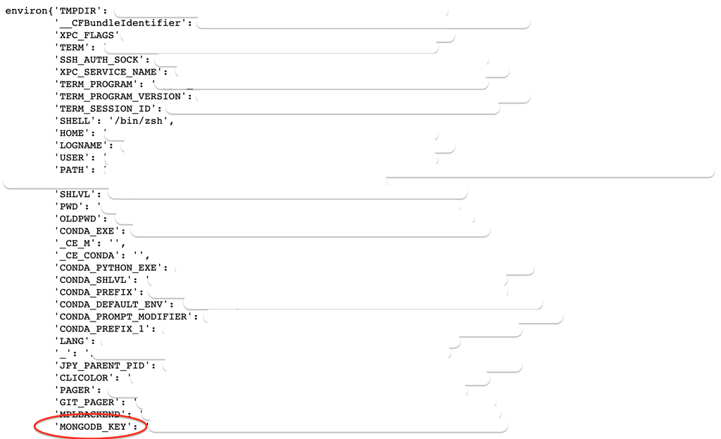

나는 MONGODB_KEY 한 줄을 입력했는데 잘 들어간 것을 확인할 수 있다.

```
load_dotenv()
os.environ['MONGODB_KEY']
```

마지막으로 주피터 노트북에 위 코드를 입력하면 해당 키가 나온다. 나는 다음과 같이 사용한다.

```
load_dotenv()
mongoadress = os.environ['MONGODB_KEY']

client = pymongo.MongoClient(mongoadress)
db = client.dbname
```

## 개인정보 잘 보호합시다!